# Building clustering

Joan Claverol Romero

02/12/2019

## GOAL

Use techniques like:

- k-means
- dendogram
- PCA

To find the closer waps to predict the buildings.

First we will use latitude and longitude, and then only the WAPs information.

## Load data

We will use for the moment the traian data. We will load the rds file preparated by the files `preparation_rds.R`:

```r
train <- read_rds("../../data/clean/train.rds")
```

Let’s see if we can use clustering techniques:

```r
train_gath <- train %>%
  # gather the WAPS to two columns: WAPs and their values
  pivot_longer(cols = starts_with("WAP"), names_to = "WAPs") %>%
  select(LONGITUDE, LATITUDE, BUILDINGID, WAPs)
```

Do we have duplicates inside our data?

- Now the dataset contains 10367240. Let’s take out the duplicates.

```r
train_unique <- train_gath %>%
  distinct_all(.keep_all = T)
```

As we want to detect the 3 main buildings, we will define as k = 3.

```r
# define set seed and apply the k-means
set.seed(123)
kmeans_results <- kmeans(
      x = train_unique %>% select(LATITUDE, LONGITUDE), # only LAT & LONG
      centers = 3 # k = 3
    )
# store your results
train_unique %<>%
  mutate(clust_kmeans = kmeans_results$cluster)
```

Let’s plot our results:

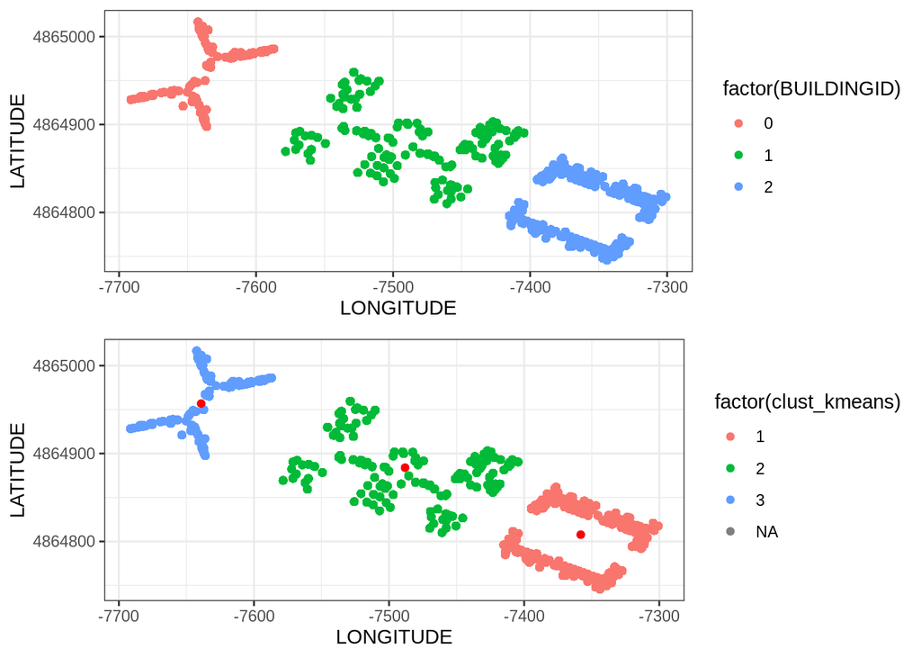

```r
# plot the real vaalues
plot_building <- train_unique %>%
  ggplot(aes(x = LONGITUDE, y = LATITUDE, col = factor(BUILDINGID))) +
    geom_point()
# plot the kmeans results
# first add the medoids in the data
train_unique <- as_tibble(kmeans_results$centers) %>%
  mutate(BUILDINGID = c(0:2), # order of k means
         WAPs = "WAPs_kmeans") %>%
  bind_rows(train_unique) # add the centers into the dataset
plot_kmeans <- train_unique %>%
  ggplot(aes(x = LONGITUDE, y = LATITUDE, col = factor(clust_kmeans))) +
    geom_point() +
    geom_point(aes(x = if_else(WAPs == "WAPs_kmeans", LONGITUDE, NULL),
                   y = if_else(WAPs == "WAPs_kmeans", LATITUDE, NULL)),
               col = "red")
# plot the results
gridExtra::grid.arrange(plot_building, plot_kmeans)
```

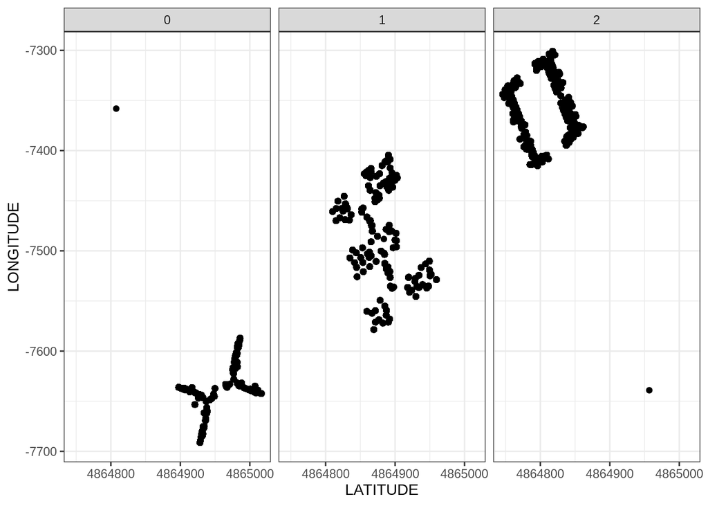

```r
train_unique %>%
  ggplot(aes(x = LATITUDE, y = LONGITUDE)) +
    geom_point() +
    facet_wrap(. ~ BUILDINGID)
```